# Project Overview

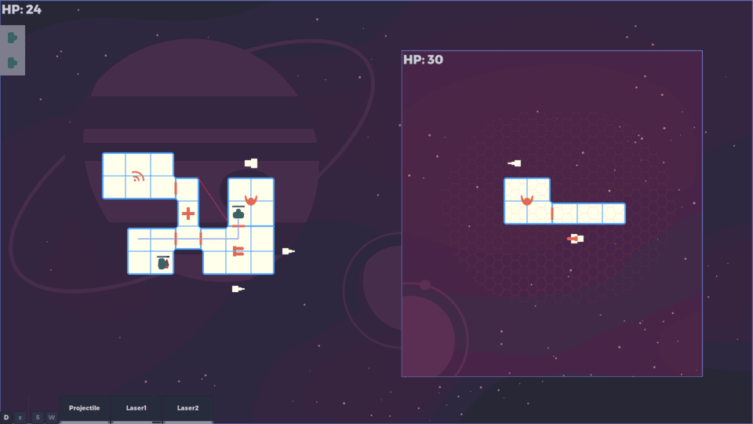

This type of project poses problems unique to its genre. Most objects in the game world have to allow a great deal of customization: ships, their rooms, weapons, and so on.

Generally, game companies build custom tools or engine plugins to facilitate this customization. Here, we don’t have the luxury of going that in-depth, so we’ll rely on Godot’s built-in capabilities instead.

The strategy is to group nodes by functionality and create sub-systems.

The ship will be in charge of coordinating these sub-systems.

## Overview

The main entry point is the `TacticalSpaceCombat.tscn` scene.

Here’s a high-level overview of the main elements of our demo.

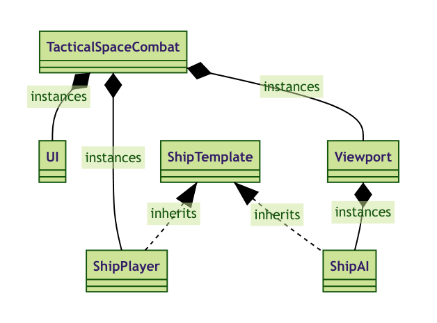

We use one class, *ShipTemplate*, that we specialize into *ShipPlayer* and *ShipAI* by attaching it to inherited scenes.

Notice that *ShipAI* is a child of a

[figure not shown]

`Viewport` node, giving it an independent game-world. We have to implement weapons that work across viewports.

Before moving on, I want to mention that the AI *Unit* nodes are stationary. They don’t implement any behavior, such as seeking hazards, dealing with them, and going back to their stations. There’s also no *Unit* to *Unit* combat.

In this demo, we focus on the ship battle strategy and implementation rather than micro-managing the units.

There is a lot of information on creating simple AI entities, so I decided to leave this topic a challenge to you to code on top of our implementation.

## The ship

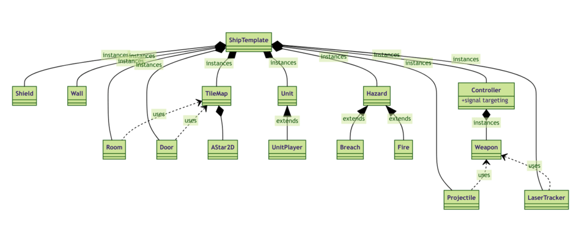

The ship is the most complex system that we have to deal with since it mediates between many smaller systems.

To be able to design it, we use the notion of *Room*. This is an

[figure not shown]

`Area2D` with a

[figure not shown]

`CollisionShape2D` node that uses a

[figure not shown]

`RectangleShape2D` resource. We take the

[figure not shown]

`RectangleShape2D` dimensions to assign tile placements in the

[figure not shown]

`TileMap` node.

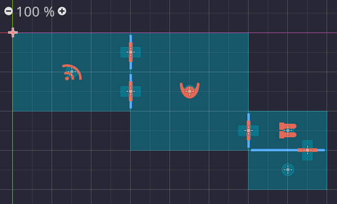

The same

[figure not shown]

`RectangleShape2D` area then defines the valid locations for our *Unit* entities, which are allowed to pass only through *Door* nodes. For finding the movement path, we use the built-in `AStar2D` node.

The ship has to deal with hazards, so it manages *Breach* and *Fire*, it can have an optional *Shield*, and finally, it can have *Controller* systems that operate the *Weapon* nodes.

Depending on their type, the *Weapon* nodes are loosely tied with the *Projectile* and *LaserTracker* systems.

## Controllers

Let’s further investigate the *Controller* system. It’s the second most complex system, after *ShipTemplate*.

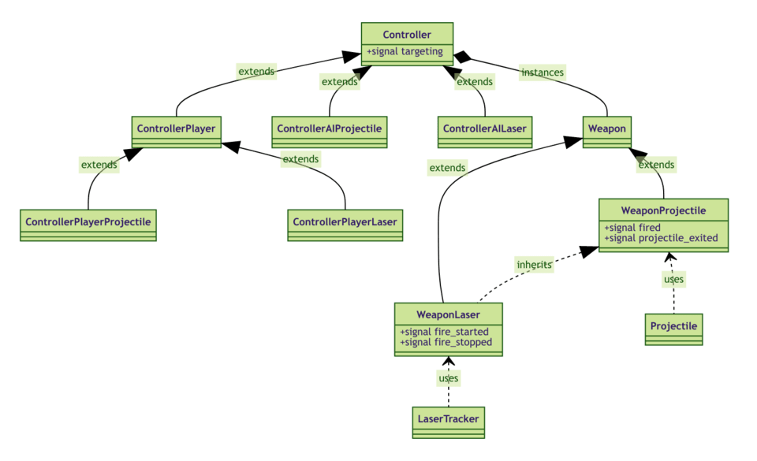

The *Controller* setup uses inheritance heavily because there’s a lot of code overlap.

What’s interesting to note is that both the *Controller* system and the *Weapon* system specialize in *Projectile* and *Laser* types.

The designer must be aware of this contract when designing a ship because *ControllerAIProjectile* and *ControllerPlayerProjectile* expect a *WeaponProjectile* node to work correctly.

And the same goes for *ControllerAILaser* and *ControllerPlayerLaser* with *WeaponLaser*.

## UI

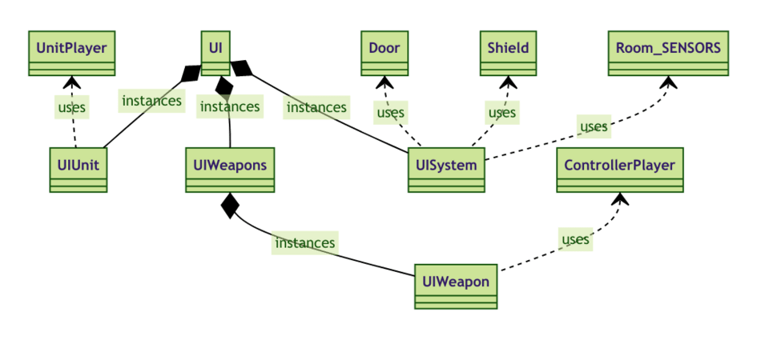

The UI is very loosely coupled with the game world.

The UI is separated into an area specific to the *UnitPlayer* interaction.

We use *UISystem* (

[figure not shown]

`Button`) as a reusable component for multiple game-world elements: *Door*, *Shield* and a specific type of *Room* - the `SENSORS` room.

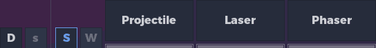

*UIWeapons* system uses the *UIWeapon* reusable component, which interacts with *ControllerPlayer* to handle *WeaponProjectile* and *WeaponLaser*.

This covers the major areas of our demo.

## Conclusion

In this lesson, we briefly went over the game systems and their responsibilities. We also looked at the overall picture of how these systems are interrelated.

We’ll go over the initial setup and prepare for building the tile-based ship template in the next part.